# Loan Data Exploration

## Preliminary Wrangling

This data set contains 113,937 loans with 81 variables on each loan, including loan amount, borrower rate (or interest rate), current loan status, borrower income, and many others.

```python
# import all packages and set plots to be embedded inline
import numpy as np
import pandas as pd
import matplotlib.pyplot as plt
import seaborn as sb

%matplotlib inline
```

```python
# load in the dataset into a pandas dataframe, print statistics
loans_origin = pd.read_csv('prosperLoanData.csv')
```

```python
loans_origin.head(5)
```

|  | ListingKey | ListingNumber | ListingCreationDate | CreditGrade | Term | LoanStatus | ClosedDate | BorrowerAPR | BorrowerRate | LenderYield | ... | LP_ServiceFees | LP_CollectionFees | LP_GrossPrincipalLoss | LP_NetPrincipalLoss | LP_NonPrincipalRecoverypayments | PercentFunded | Recommendations | InvestmentFromFriendsCount | InvestmentFromFriendsAmount | Investors |
| --- | --- | --- | --- | --- | --- | --- | --- | --- | --- | --- | --- | --- | --- | --- | --- | --- | --- | --- | --- | --- | --- |
| 0 | 1021339766868145413AB3B | 193129 | 2007-08-26 19:09:29.263000000 | C | 36 | Completed | 2009-08-14 00:00:00 | 0.16516 | 0.1580 | 0.1380 | ... | -133.18 | 0.0 | 0.0 | 0.0 | 0.0 | 1.0 | 0 | 0 | 0.0 | 258 |
| 1 | 10273602499503308B223C1 | 1209647 | 2014-02-27 08:28:07.900000000 | NaN | 36 | Current | NaN | 0.12016 | 0.0920 | 0.0820 | ... | 0.00 | 0.0 | 0.0 | 0.0 | 0.0 | 1.0 | 0 | 0 | 0.0 | 1 |
| 2 | 0EE9337825851032864889A | 81716 | 2007-01-05 15:00:47.090000000 | HR | 36 | Completed | 2009-12-17 00:00:00 | 0.28269 | 0.2750 | 0.2400 | ... | -24.20 | 0.0 | 0.0 | 0.0 | 0.0 | 1.0 | 0 | 0 | 0.0 | 41 |
| 3 | 0EF5356002482715299901A | 658116 | 2012-10-22 11:02:35.010000000 | NaN | 36 | Current | NaN | 0.12528 | 0.0974 | 0.0874 | ... | -108.01 | 0.0 | 0.0 | 0.0 | 0.0 | 1.0 | 0 | 0 | 0.0 | 158 |
| 4 | 0F023589499656230C5E3E2 | 909464 | 2013-09-14 18:38:39.097000000 | NaN | 36 | Current | NaN | 0.24614 | 0.2085 | 0.1985 | ... | -60.27 | 0.0 | 0.0 | 0.0 | 0.0 | 1.0 | 0 | 0 | 0.0 | 20 |

5 rows × 81 columns

```python
# high-level overview of data shape and composition
print(loans_origin.shape)
print(loans_origin.info())
```

```
(113937, 81)
<class 'pandas.core.frame.DataFrame'>
RangeIndex: 113937 entries, 0 to 113936
Data columns (total 81 columns):
ListingKey                             113937 non-null object
ListingNumber                          113937 non-null int64
ListingCreationDate                    113937 non-null object
CreditGrade                            28953 non-null object
Term                                   113937 non-null int64
LoanStatus                             113937 non-null object
ClosedDate                             55089 non-null object
BorrowerAPR                            113912 non-null float64
BorrowerRate                           113937 non-null float64
LenderYield                            113937 non-null float64
EstimatedEffectiveYield                84853 non-null float64
EstimatedLoss                          84853 non-null float64
EstimatedReturn                        84853 non-null float64
ProsperRating (numeric)                84853 non-null float64
ProsperRating (Alpha)                  84853 non-null object
ProsperScore                           84853 non-null float64
ListingCategory (numeric)              113937 non-null int64
BorrowerState                          108422 non-null object
Occupation                             110349 non-null object
EmploymentStatus                       111682 non-null object
EmploymentStatusDuration               106312 non-null float64
IsBorrowerHomeowner                    113937 non-null bool
CurrentlyInGroup                       113937 non-null bool
GroupKey                               13341 non-null object
DateCreditPulled                       113937 non-null object
CreditScoreRangeLower                  113346 non-null float64
CreditScoreRangeUpper                  113346 non-null float64
FirstRecordedCreditLine                113240 non-null object
CurrentCreditLines                     106333 non-null float64
OpenCreditLines                        106333 non-null float64
TotalCreditLinespast7years             113240 non-null float64
OpenRevolvingAccounts                  113937 non-null int64
OpenRevolvingMonthlyPayment            113937 non-null float64
InquiriesLast6Months                   113240 non-null float64
TotalInquiries                         112778 non-null float64
CurrentDelinquencies                   113240 non-null float64
```

[output cut: 33 more lines]

```
LP_CustomerPrincipalPayments           113937 non-null float64
LP_InterestandFees                     113937 non-null float64
LP_ServiceFees                         113937 non-null float64
LP_CollectionFees                      113937 non-null float64
LP_GrossPrincipalLoss                  113937 non-null float64
LP_NetPrincipalLoss                    113937 non-null float64
LP_NonPrincipalRecoverypayments        113937 non-null float64
PercentFunded                          113937 non-null float64
Recommendations                        113937 non-null int64
InvestmentFromFriendsCount             113937 non-null int64
InvestmentFromFriendsAmount            113937 non-null float64
Investors                              113937 non-null int64
dtypes: bool(3), float64(50), int64(11), object(17)
memory usage: 68.1+ MB
None
```

```python
#chose important values for further exploration

loans = loans_origin[['CreditGrade','Term', 'ListingCreationDate', 'LoanStatus', 'BorrowerAPR', 'BorrowerRate',
       'LenderYield', 'EstimatedEffectiveYield', 'EstimatedLoss','EstimatedReturn', 'ProsperRating (numeric)',
       'ProsperRating (Alpha)', 'ProsperScore', 'ListingCategory (numeric)', 'EmploymentStatus', 'EmploymentStatusDuration',
       'IsBorrowerHomeowner', 'CurrentCreditLines', 'OpenCreditLines', 'TotalCreditLinespast7years', 'OpenRevolvingAccounts', 'OpenRevolvingMonthlyPayment', 'InquiriesLast6Months', 'TotalInquiries',
       'CurrentDelinquencies', 'AmountDelinquent', 'PublicRecordsLast10Years', 'PublicRecordsLast12Months',
       'RevolvingCreditBalance', 'DelinquenciesLast7Years', 'TradesNeverDelinquent (percentage)', 'TradesOpenedLast6Months','BankcardUtilization',
       'DebtToIncomeRatio', 'IncomeRange', 'StatedMonthlyIncome', 'TotalProsperPaymentsBilled', 'OnTimeProsperPayments',
       'ProsperPaymentsLessThanOneMonthLate', 'ProsperPaymentsOneMonthPlusLate', 'ProsperPrincipalBorrowed',
       'ProsperPrincipalOutstanding', 'ScorexChangeAtTimeOfListing', 'LoanCurrentDaysDelinquent',
       'LoanOriginalAmount', 'LoanOriginationDate', 'LoanOriginationQuarter', 'MonthlyLoanPayment', 'LP_CustomerPayments', 'LP_CustomerPrincipalPayments', 'LP_InterestandFees', 'LP_ServiceFees',
       'LP_CollectionFees', 'LP_GrossPrincipalLoss', 'LP_NetPrincipalLoss', 'LP_NonPrincipalRecoverypayments']]
loans.info()
```

```
<class 'pandas.core.frame.DataFrame'>
RangeIndex: 113937 entries, 0 to 113936
Data columns (total 56 columns):
CreditGrade                            28953 non-null object
Term                                   113937 non-null int64
ListingCreationDate                    113937 non-null object
LoanStatus                             113937 non-null object
BorrowerAPR                            113912 non-null float64
BorrowerRate                           113937 non-null float64
LenderYield                            113937 non-null float64
EstimatedEffectiveYield                84853 non-null float64
EstimatedLoss                          84853 non-null float64
EstimatedReturn                        84853 non-null float64
ProsperRating (numeric)                84853 non-null float64
ProsperRating (Alpha)                  84853 non-null object
ProsperScore                           84853 non-null float64
ListingCategory (numeric)              113937 non-null int64
EmploymentStatus                       111682 non-null object
EmploymentStatusDuration               106312 non-null float64
IsBorrowerHomeowner                    113937 non-null bool
CurrentCreditLines                     106333 non-null float64
OpenCreditLines                        106333 non-null float64
TotalCreditLinespast7years             113240 non-null float64
OpenRevolvingAccounts                  113937 non-null int64
OpenRevolvingMonthlyPayment            113937 non-null float64
InquiriesLast6Months                   113240 non-null float64
TotalInquiries                         112778 non-null float64
CurrentDelinquencies                   113240 non-null float64
AmountDelinquent                       106315 non-null float64
PublicRecordsLast10Years               113240 non-null float64
PublicRecordsLast12Months              106333 non-null float64
RevolvingCreditBalance                 106333 non-null float64
DelinquenciesLast7Years                112947 non-null float64
TradesNeverDelinquent (percentage)     106393 non-null float64
TradesOpenedLast6Months                106393 non-null float64
BankcardUtilization                    106333 non-null float64
DebtToIncomeRatio                      105383 non-null float64
IncomeRange                            113937 non-null object
StatedMonthlyIncome                    113937 non-null float64
TotalProsperPaymentsBilled             22085 non-null float64
OnTimeProsperPayments                  22085 non-null float64
ProsperPaymentsLessThanOneMonthLate    22085 non-null float64
ProsperPaymentsOneMonthPlusLate        22085 non-null float64
ProsperPrincipalBorrowed               22085 non-null float64
ProsperPrincipalOutstanding            22085 non-null float64
ScorexChangeAtTimeOfListing            18928 non-null float64
LoanCurrentDaysDelinquent              113937 non-null int64
LoanOriginalAmount                     113937 non-null int64
LoanOriginationDate                    113937 non-null object
LoanOriginationQuarter                 113937 non-null object
MonthlyLoanPayment                     113937 non-null float64
LP_CustomerPayments                    113937 non-null float64
LP_CustomerPrincipalPayments           113937 non-null float64
LP_InterestandFees                     113937 non-null float64
LP_ServiceFees                         113937 non-null float64
LP_CollectionFees                      113937 non-null float64
LP_GrossPrincipalLoss                  113937 non-null float64
LP_NetPrincipalLoss                    113937 non-null float64
LP_NonPrincipalRecoverypayments        113937 non-null float64
dtypes: bool(1), float64(42), int64(5), object(8)
memory usage: 47.9+ MB
```

```python
#briefly look at the CreditGrade values
loans.CreditGrade.value_counts()
```

```
C     5649
D     5153
B     4389
AA    3509
HR    3508
A     3315
E     3289
NC     141
Name: CreditGrade, dtype: int64
```

```python
#briefly look at the Term values
loans.Term.value_counts()
```

```
36    87778
60    24545
12     1614
Name: Term, dtype: int64
```

```python
#briefly look at the LoanStatus values
loans.LoanStatus.value_counts().index
```

```
Index(['Current', 'Completed', 'Chargedoff', 'Defaulted',
       'Past Due (1-15 days)', 'Past Due (31-60 days)',
       'Past Due (61-90 days)', 'Past Due (91-120 days)',
       'Past Due (16-30 days)', 'FinalPaymentInProgress',
       'Past Due (>120 days)', 'Cancelled'],
      dtype='object')
```

```python
#briefly look at the BorrowerAPR values
loans['BorrowerAPR'].describe()
```

```
count    113912.000000
mean          0.218828
std           0.080364
min           0.006530
25%           0.156290
50%           0.209760
75%           0.283810
max           0.512290
Name: BorrowerAPR, dtype: float64
```

```python
#briefly look at the BorrowerRate values
loans['BorrowerRate'].describe()
```

```
count    113937.000000
mean          0.192764
std           0.074818
min           0.000000
25%           0.134000
50%           0.184000
75%           0.250000
max           0.497500
Name: BorrowerRate, dtype: float64
```

```python
#briefly look at the LenderYield values
loans['LenderYield'].describe()
```

```
count    113937.000000
mean          0.182701
std           0.074516
min          -0.010000
25%           0.124200
50%           0.173000
75%           0.240000
max           0.492500
Name: LenderYield, dtype: float64
```

```python
#briefly look at the EstimatedEffectiveYield values
loans['EstimatedEffectiveYield'].describe()
```

```
count    84853.000000
mean         0.168661
std          0.068467
min         -0.182700
25%          0.115670
50%          0.161500
75%          0.224300
max          0.319900
Name: EstimatedEffectiveYield, dtype: float64
```

```python
#briefly look at the EstimatedLoss values
loans['EstimatedLoss'].describe()
```

```
count    84853.000000
mean         0.080306
std          0.046764
min          0.004900
25%          0.042400
50%          0.072400
75%          0.112000
max          0.366000
Name: EstimatedLoss, dtype: float64
```

```python
#briefly look at the EstimatedReturn values
loans['EstimatedReturn'].describe()
```

```
count    84853.000000
mean         0.096068
std          0.030403
min         -0.182700
25%          0.074080
50%          0.091700
75%          0.116600
max          0.283700
Name: EstimatedReturn, dtype: float64
```

```python
#briefly look at the ProsperRating (numeric) values
loans['ProsperRating (numeric)'].value_counts()
```

```
4.0    18345
5.0    15581
6.0    14551
3.0    14274
2.0     9795
1.0     6935
7.0     5372
Name: ProsperRating (numeric), dtype: int64
```

```python
#briefly look at the ProsperRating (Alpha) values
loans['ProsperRating (Alpha)'].value_counts()
```

```
C     18345
B     15581
A     14551
D     14274
E      9795
HR     6935
AA     5372
Name: ProsperRating (Alpha), dtype: int64
```

```python
#briefly look at the ProsperScore values
loans['ProsperScore'].value_counts()
```

```
4.0     12595
6.0     12278
8.0     12053
7.0     10597
5.0      9813
3.0      7642
9.0      6911
2.0      5766
10.0     4750
11.0     1456
1.0       992
Name: ProsperScore, dtype: int64
```

```python
#briefly look at the ListingCategory (numeric) values
loans['ListingCategory (numeric)'].value_counts()
```

```
1     58308
0     16965
7     10494
2      7433
3      7189
6      2572
4      2395
13     1996
15     1522
18      885
14      876
20      771
19      768
5       756
16      304
11      217
8       199
10       91
9        85
12       59
17       52
Name: ListingCategory (numeric), dtype: int64
```

```python
#briefly look at the EmploymentStatus values
loans['EmploymentStatus'].value_counts()
```

```
Employed         67322
Full-time        26355
Self-employed     6134
Not available     5347
Other             3806
Part-time         1088
Not employed       835
Retired            795
Name: EmploymentStatus, dtype: int64
```

```python
#briefly look at the EmploymentStatusDuration values
loans['EmploymentStatusDuration'].describe()
```

```
count    106312.000000
mean         96.071582
std          94.480605
min           0.000000
25%          26.000000
50%          67.000000
75%         137.000000
max         755.000000
Name: EmploymentStatusDuration, dtype: float64
```

```python
#briefly look at the IsBorrowerHomeowner values
loans['IsBorrowerHomeowner'].value_counts()
```

```
True     57478
False    56459
Name: IsBorrowerHomeowner, dtype: int64
```

```python
#briefly look at the CurrentCreditLines values
loans['CurrentCreditLines'].describe()
```

```
count    106333.000000
mean         10.317192
std           5.457866
min           0.000000
25%           7.000000
50%          10.000000
75%          13.000000
max          59.000000
Name: CurrentCreditLines, dtype: float64
```

```python
#briefly look at the OpenCreditLines values
loans['OpenCreditLines'].describe()
```

```
count    106333.000000
mean          9.260164
std           5.022644
min           0.000000
25%           6.000000
50%           9.000000
75%          12.000000
max          54.000000
Name: OpenCreditLines, dtype: float64
```

```python
#briefly look at the TotalCreditLinespast7years values
loans['TotalCreditLinespast7years'].describe()
```

```
count    113240.000000
mean         26.754539
std          13.637871
min           2.000000
25%          17.000000
50%          25.000000
75%          35.000000
max         136.000000
Name: TotalCreditLinespast7years, dtype: float64
```

```python
#briefly look at the OpenRevolvingMonthlyPayment values
loans['OpenRevolvingMonthlyPayment'].describe()
```

```
count    113937.000000
mean        398.292161
std         447.159711
min           0.000000
25%         114.000000
50%         271.000000
75%         525.000000
max       14985.000000
Name: OpenRevolvingMonthlyPayment, dtype: float64
```

```python
#briefly look at the CurrentDelinquencies values
loans['CurrentDelinquencies'].describe()
```

```
count    113240.000000
mean          0.592052
std           1.978707
min           0.000000
25%           0.000000
50%           0.000000
75%           0.000000
max          83.000000
Name: CurrentDelinquencies, dtype: float64
```

```python
loans['BankcardUtilization'].describe()
```

```
count    106333.000000
mean          0.561309
std           0.317918
min           0.000000
25%           0.310000
50%           0.600000
75%           0.840000
max           5.950000
Name: BankcardUtilization, dtype: float64
```

```python
#group the borrowers to 5 groups (mild use,medium use,heavy use,super use,no use）according to the BankcardUtilization
#'no use' is used for borrowers showing "o" or "NA"

oneforth=loans['BankcardUtilization'].quantile(0.25)
twoforth=loans['BankcardUtilization'].quantile(0.5)

def switch_data1(x):
    if 0<x<0.31:
        y='Mild Use'
    elif 0.31<=x<0.6:
        y='Medium Use'
    elif 0.6<=x<=1:
        y='Heavy Use'
    elif x>1:
        y='Super Use'
    else:
        y='No Use'
    return y

loans['BankcardUse']=loans['BankcardUtilization'].apply(switch_data1)
```

```python
#briefly look at the AmountDelinquent values
loans['AmountDelinquent'].describe()
```

```
count    106315.000000
mean        984.507059
std        7158.270157
min           0.000000
25%           0.000000
50%           0.000000
75%           0.000000
max      463881.000000
Name: AmountDelinquent, dtype: float64
```

```python
#briefly look at the RevolvingCreditBalance values
loans['RevolvingCreditBalance'].describe()
```

```
count    1.063330e+05
mean     1.759871e+04
std      3.293640e+04
min      0.000000e+00
25%      3.121000e+03
50%      8.549000e+03
75%      1.952100e+04
max      1.435667e+06
Name: RevolvingCreditBalance, dtype: float64
```

```python
#briefly look at the StatedMonthlyIncome values
loans['StatedMonthlyIncome'].describe()
```

```
count    1.139370e+05
mean     5.608026e+03
std      7.478497e+03
min      0.000000e+00
25%      3.200333e+03
50%      4.666667e+03
75%      6.825000e+03
max      1.750003e+06
Name: StatedMonthlyIncome, dtype: float64
```

```python
#briefly look at the LoanOriginalAmount values
loans['LoanOriginalAmount'].describe()
```

```
count    113937.00000
mean       8337.01385
std        6245.80058
min        1000.00000
25%        4000.00000
50%        6500.00000
75%       12000.00000
max       35000.00000
Name: LoanOriginalAmount, dtype: float64
```

```python
#briefly look at the LoanOriginalDate values
loans['LoanOriginationDate'].describe()
```

```
count                  113937
unique                   1873
top       2014-01-22 00:00:00
freq                      491
Name: LoanOriginationDate, dtype: object
```

```python
#the credit score systems are different before and after 2009-7-1, so it needs to be seperated according to the LoanOriginationDate
def date_phase(x):
    if x>='2009-07-01':
        y='After 2009'
    else:
        y='Before 2009'
    return y
#add new column to show the difference
loans['DatePhase']=loans['LoanOriginationDate'].apply(date_phase)
```

```python
#split the ListingCreationDate to year, month, quater and day for further analysis
#change the data type of ListingCreationDate to date

loans['LoanOriginationYear'] = loans['LoanOriginationDate'].str[:4]
loans['LoanOriginationMonth'] = loans['LoanOriginationDate'].str[5:7]
loans['LoanOriginationDay'] = loans['LoanOriginationDate'].str[8:10]
loans['LoanOriginationQtr'] = pd.PeriodIndex(pd.to_datetime(loans['LoanOriginationDate'].str[:7]), freq='Q')
loans['LoanOriginationDate'] = pd.to_datetime(loans['LoanOriginationDate'].str[:10])
print(loans.LoanOriginationDate.describe())
print(loans.LoanOriginationYear.describe())
print(loans.LoanOriginationMonth.describe())
print(loans.LoanOriginationQtr.describe())
print(loans.LoanOriginationDay.describe())
```

```
count                  113937
unique                   1873
top       2014-01-22 00:00:00
freq                      491
first     2005-11-15 00:00:00
last      2014-03-12 00:00:00
Name: LoanOriginationDate, dtype: object
count     113937
unique        10
top         2013
freq       34345
Name: LoanOriginationYear, dtype: object
count     113937
unique        12
top           01
freq       11395
Name: LoanOriginationMonth, dtype: object
count     113937
unique        33
top       2013Q4
freq       14450
Name: LoanOriginationQtr, dtype: object
count     113937
unique        31
top           30
freq        4812
Name: LoanOriginationDay, dtype: object
```

```python
#briefly look at the MonthlyLoanPayment values
loans['MonthlyLoanPayment'].describe()
```

```
count    113937.000000
mean        272.475783
std         192.697812
min           0.000000
25%         131.620000
50%         217.740000
75%         371.580000
max        2251.510000
Name: MonthlyLoanPayment, dtype: float64
```

```python
#briefly look at the DebtToIncomeRatio values
loans['DebtToIncomeRatio'].value_counts()
```

```
0.18000    4132
0.22000    3687
0.17000    3616
0.14000    3553
0.20000    3481
0.16000    3442
0.19000    3392
0.15000    3338
0.21000    3226
0.13000    3169
0.24000    2952
0.23000    2882
0.25000    2873
0.12000    2799
0.26000    2789
0.11000    2726
0.27000    2722
0.28000    2598
0.29000    2348
0.30000    2348
0.10000    2326
0.08000    2230
0.31000    2179
0.32000    2073
0.09000    1964
0.33000    1902
0.35000    1812
0.34000    1810
0.07000    1759
0.06000    1523
           ...
0.16164       1
0.10696       1
6.95000       1
7.59000       1
0.08582       1
0.11773       1
0.04850       1
0.02343       1
0.02287       1
0.04793       1
0.34443       1
8.53000       1
0.04758       1
0.02685       1
0.08128       1
0.17150       1
0.13657       1
0.06154       1
3.71000       1
0.15450       1
0.05588       1
0.04475       1
0.03909       1
0.34452       1
0.09206       1
0.13774       1
0.04983       1
0.15248       1
0.19893       1
0.06056       1
Name: DebtToIncomeRatio, Length: 1207, dtype: int64
```

### What is the structure of your dataset?

```python
# convert cut, color, and clarity into ordered categorical types
ordinal_var_dict = {'CreditGrade': ['NC', 'HR', 'E', 'D', 'C', 'B', 'A', 'AA'],
                    'ProsperRating (Alpha)': ['HR', 'E', 'D', 'C', 'B', 'A', 'AA'],
                    'IncomeRange': ['Not displayed', 'Not employed', '$0', '$1-24,999', '$25,000-49,999',
                                    '$50,000-74,999', '$75,000-99,999', '$100,000+'],
                    'LoanStatus': ['Current', 'Completed', 'Chargedoff', 'Defaulted',
                                   'Past Due (1-15 days)', 'Past Due (31-60 days)',
                                   'Past Due (61-90 days)', 'Past Due (91-120 days)',
                                   'Past Due (16-30 days)', 'FinalPaymentInProgress',
                                   'Past Due (>120 days)', 'Cancelled']}

for var in ordinal_var_dict:
    ordered_var = pd.api.types.CategoricalDtype(ordered = True,
                                                categories = ordinal_var_dict[var])
    loans[var] = loans[var].astype(ordered_var)
```

### What is/are the main feature(s) of interest in your dataset?

I'm most interested in figuring out the following questions:

1. What factors affect a loan’s outcome status?
2. What affects the borrower’s APR or interest rate?
3. Are there differences between loans depending on how large the original loan amount was?

### What features in the dataset do you think will help support your investigation into your feature(s) of interest?

I'll look through the features including CreditGrade, Term, LoanStatus, BorrowerAPR, BorrowerRate, LenderYield, EstimatedEffectiveYield, ProsperRating, ListingCategory (numeric), EmploymentStatus, EmploymentStatusDuration, IsBorrowerHomeowner, OpenRevolvingMonthlyPayment, DelinquenciesLast7Years, BankcardUtilization, DebtToIncomeRatio, IncomeRange, StatedMonthlyIncome, LoanOriginalAmount, LoanOriginationDate, LoanOriginationQuarter, MonthlyLoanPayment.

## Univariate Exploration

1. The first variable I want to look at is CreditGrade.

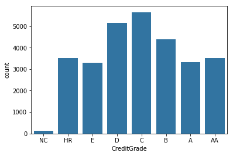

```python
# CreditGrade was used before 2009

base_color = sb.color_palette()[0]
sb.countplot(data = loans[loans['DatePhase'] == 'Before 2009'], x = 'CreditGrade', color = base_color)
```

Among the different grade levels, the most common creditgrades are B, C and D.

1. Let's look at the similer Prosper ratings and score, which is a custom risk ratings and score built using historical Prosper data, applicable in loans after July 2009.

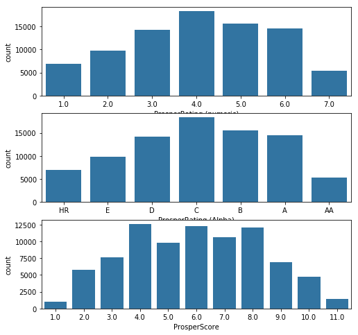

```python
#Prosper scores are used after 2009

fig, ax = plt.subplots(nrows=3, figsize = [8,8])

default_color = sb.color_palette()[0]
sb.countplot(data = loans[loans['DatePhase'] == 'After 2009'], x = 'ProsperRating (numeric)', color = default_color, ax = ax[0])
sb.countplot(data = loans[loans['DatePhase'] == 'After 2009'], x = 'ProsperRating (Alpha)', color = default_color, ax = ax[1])
sb.countplot(data = loans[loans['DatePhase'] == 'After 2009'], x = 'ProsperScore', color = default_color, ax = ax[2])

plt.show()
```

Compared to the credit grade figure, the prosper ratings showed similar but better patterns.

1. Then let's look at how long people usually opt for loans (Term).

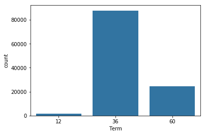

```python
base_color = sb.color_palette()[0]
sb.countplot(data = loans, x = 'Term', color = base_color)
```

Among three terms of loans: 12, 36 and 60 months, the majority of loans are under 36 months, followed by 60 months, and very few are under 12 months.

1. How about the time of the loans?

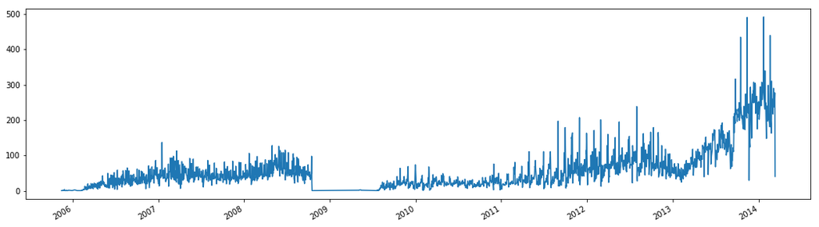

```python
# plot a line of the dates
plt.figure(figsize=[18, 5])
date = loans['LoanOriginationDate'].value_counts().sort_index()
ax = date.plot('line')
```

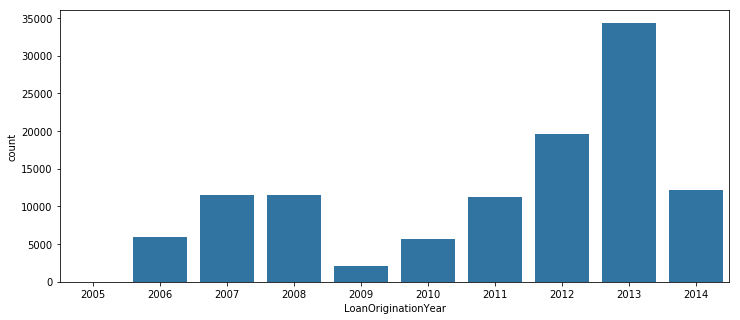

```python
# barplot shows the trends of years
plt.figure(figsize=[12, 5])
base_color = sb.color_palette()[0]
sb.countplot(data = loans, x = 'LoanOriginationYear', color = base_color)
```

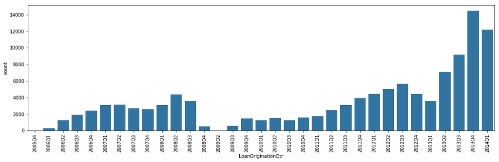

```python
# barplot shows the trends of quarters
plt.figure(figsize=[18, 5])
base_color = sb.color_palette()[0]
qtr_order = loans['LoanOriginationQtr'].value_counts().index.sort_values()
sb.countplot(data = loans, x = 'LoanOriginationQtr', color = base_color, order = qtr_order)
plt.xticks(rotation = 90)
```

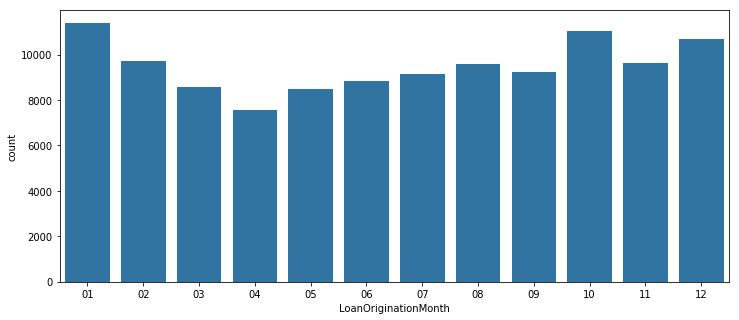

```python
# barplot shows the trends of months
plt.figure(figsize=[12, 5])
base_color = sb.color_palette()[0]
sb.countplot(data = loans, x = 'LoanOriginationMonth', color = base_color)
```

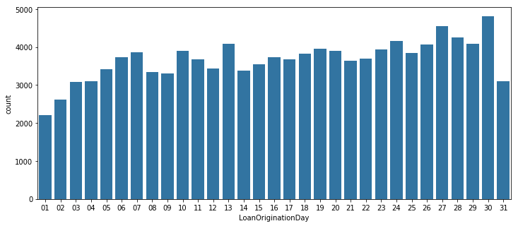

```python
# barplot shows the trends of days
plt.figure(figsize=[12, 5])
base_color = sb.color_palette()[0]
sb.countplot(data = loans, x = 'LoanOriginationDay', color = base_color)
```

1. Let's also have a look at the LoanStatus.

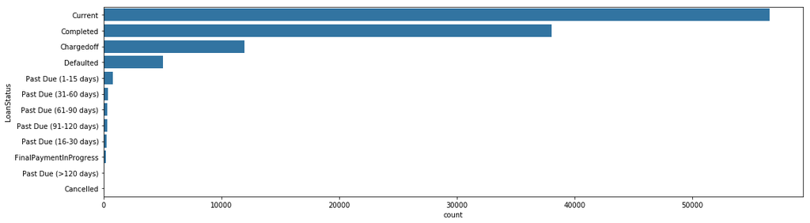

```python
plt.figure(figsize=[18, 5])
base_color = sb.color_palette()[0]
sb.countplot(data = loans, y = 'LoanStatus', color = base_color)
```

```python
# set up new column called Loan_status_new, and combine all the past due loans together
# cancelled loans are only 5, so they are simply excluded

loans=loans[loans['LoanStatus']!='Cancelled']

loans['Loan_status_new'] = 'None'

# iterate through all the rows of df table
for i, row in loans.iterrows():
    if row.LoanStatus == 'Current':
        loans.set_value(i, 'Loan_status_new', row.LoanStatus)
    elif row.LoanStatus == 'Completed':
        loans.set_value(i, 'Loan_status_new', row.LoanStatus)
    elif row.LoanStatus == 'Chargedoff' or row.LoanStatus == 'Defaulted':
        loans.set_value(i, 'Loan_status_new', 'Defaulted')
    else:
        loans.set_value(i, 'Loan_status_new', 'Past due')
```

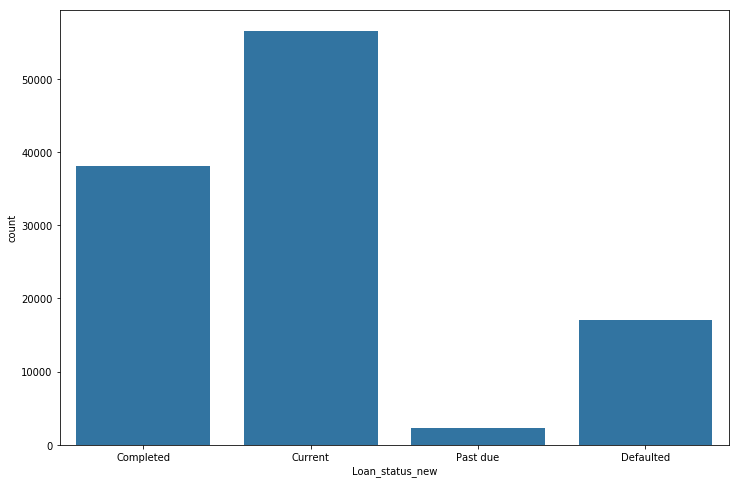

```python
plt.figure(figsize=[12, 8])
base_color = sb.color_palette()[0]
sb.countplot(data = loans, x = 'Loan_status_new', color = base_color)
```

1. BorrowerAPR: the Borrower's Annual Percentage Rate (APR) for the loan, the highest rates are around 0.35, and the rest rates showed a slightly right skewed distribution with the highest rates around 0.2.

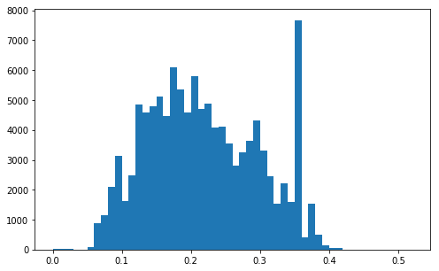

```python
loans['BorrowerAPR'] = loans['BorrowerAPR'].fillna(0.0)

binsize = 0.01
bins = np.arange(0, loans['BorrowerAPR'].max()+binsize, binsize)

plt.figure(figsize=[8, 5])
plt.hist(data = loans, x = 'BorrowerAPR', bins = bins)
plt.show()
```

1. BorrowerRate: the Borrower's interest rate for this loan, the highest rates are around 0.31, and the rest rates showed a slightly right skewed distribution with the highest rates around 0.15.

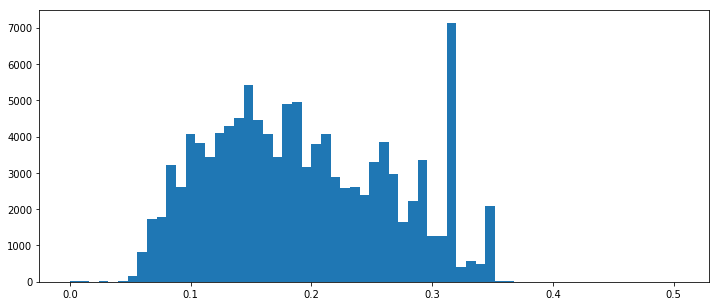

```python
loans['BorrowerRate'] = loans['BorrowerRate'].fillna(0.0)

binsize = 0.008
bins = np.arange(0, loans['BorrowerRate'].max()+binsize, binsize)

plt.figure(figsize=[12, 5])
plt.hist(data = loans, x = 'BorrowerRate', bins = bins)
plt.show()
```

1. EmploymentStatus: majority of the borrowers are employed.

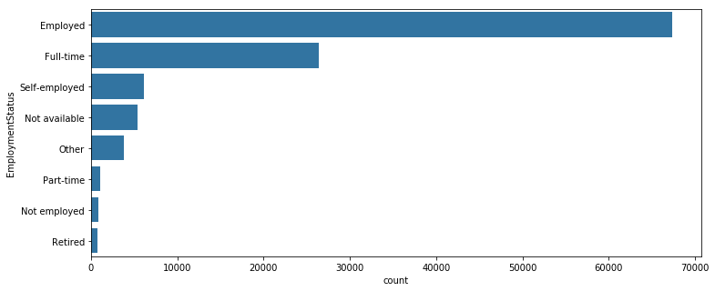

```python
plt.figure(figsize=[12, 5])
base_color = sb.color_palette()[0]
sb.countplot(data = loans, y = 'EmploymentStatus', color = base_color,
             order = loans['EmploymentStatus'].value_counts().index)
```

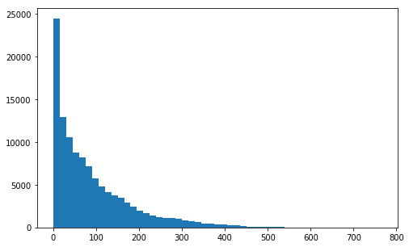

```python
# normal histogram

loans['EmploymentStatusDuration'] = loans['EmploymentStatusDuration'].fillna(0.0)

binsize = 15
bins = np.arange(0, loans['EmploymentStatusDuration'].max()+binsize, binsize)

plt.figure(figsize=[8, 5])
plt.hist(data = loans, x = 'EmploymentStatusDuration', bins = bins)
plt.show()
```

```python
# there's a long tail in the distribution, so let's put it on a log scale instead
# firstly have a look at the values after log10

np.log10(loans['EmploymentStatusDuration']).describe()
```

```
count    1.139320e+05
mean             -inf
std               NaN
min              -inf
25%      1.278754e+00
50%      1.778151e+00
75%      2.113943e+00
max      2.877947e+00
Name: EmploymentStatusDuration, dtype: float64
```

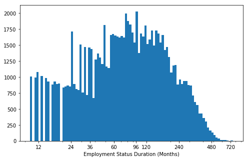

```python
# tranmit to a log scale

log_binsize = 0.02
bins = 10 ** np.arange(1, np.log10(loans['EmploymentStatusDuration'].max())+log_binsize, log_binsize)

plt.figure(figsize=[8, 5])
plt.hist(data = loans, x = 'EmploymentStatusDuration', bins = bins)
plt.xscale('log')
plt.xticks([12, 24, 36, 60, 96, 120, 240, 480, 720], [12, 24, 36, 60, 96, 120, 240, 480, 720])
plt.xlabel('Employment Status Duration (Months)')
plt.show()
```

1. IsBorrowerHomeowner: the percentage of homeowners is around 50%, so it is unlikely the affector of loan outcomes or others.

```
(-1.1020323996777344,
 1.1038630732432577,
 -1.103497272486668,
 1.102398200434324)
```

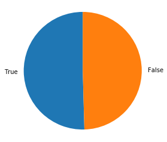

```python
counts = loans['IsBorrowerHomeowner'].value_counts()
plt.pie(counts, labels = counts.index, startangle = 90)
plt.axis('square')
```

1. CreditLines: CurrentCreditLines, OpenCreditLines, TotalCreditLinespast7years showed the simiar patterns: slightly right skewed distribution.

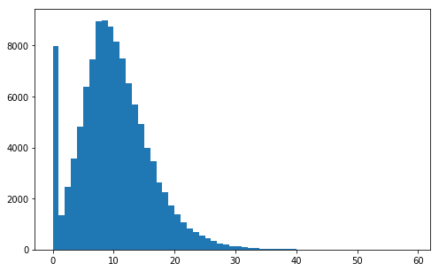

```python
loans['CurrentCreditLines'] = loans['CurrentCreditLines'].fillna(0.0).astype(int)

binsize = 1
bins = np.arange(0, loans['CurrentCreditLines'].max()+binsize, binsize)

plt.figure(figsize=[8, 5])
plt.hist(data = loans, x = 'CurrentCreditLines', bins = bins)
plt.show()
```

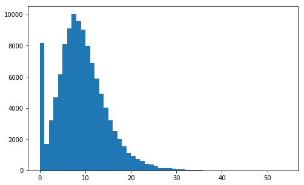

```python
loans['OpenCreditLines'] = loans['OpenCreditLines'].fillna(0.0).astype(int)

binsize = 1
bins = np.arange(0, loans['OpenCreditLines'].max()+binsize, binsize)

plt.figure(figsize=[8, 5])
plt.hist(data = loans, x = 'OpenCreditLines', bins = bins)
plt.show()
```

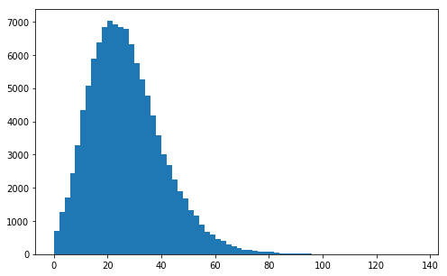

```python
loans['TotalCreditLinespast7years'] = loans['TotalCreditLinespast7years'].fillna(0.0).astype(int)

binsize = 2
bins = np.arange(0, loans['TotalCreditLinespast7years'].max()+binsize, binsize)

plt.figure(figsize=[8, 5])
plt.hist(data = loans, x = 'TotalCreditLinespast7years', bins = bins)
plt.show()
```

1. OpenRevolvingMonthlyPayment: monthly payment on revolving accounts at the time the credit profile was pulled. Most cases the amount is around 300-400.

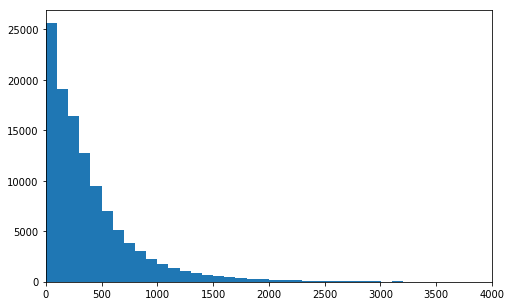

```python
# start with a standard-scaled plot
loans['OpenRevolvingMonthlyPayment'] = loans['OpenRevolvingMonthlyPayment'].fillna(0.0).astype(int)

binsize = 100
bins = np.arange(0, loans['OpenRevolvingMonthlyPayment'].max()+binsize, binsize)

plt.figure(figsize=[8, 5])
plt.hist(data = loans, x = 'OpenRevolvingMonthlyPayment', bins = bins)
plt.xlim(0, 4000)
plt.show()
```

```python
# there's a long tail in the distribution, so let's put it on a log scale instead
np.log10(loans['OpenRevolvingMonthlyPayment']).describe()
```

```
count    1.139320e+05
mean             -inf
std               NaN
min              -inf
25%      2.056905e+00
50%      2.432969e+00
75%      2.720159e+00
max      4.175657e+00
Name: OpenRevolvingMonthlyPayment, dtype: float64
```

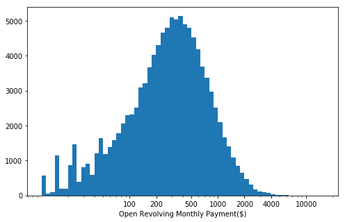

```python
# transfer to a log scale figure

log_binsize = 0.05
bins = 10 ** np.arange(1, np.log10(loans['OpenRevolvingMonthlyPayment'].max())+log_binsize, log_binsize)

plt.figure(figsize=[8, 5])
plt.hist(data = loans, x = 'OpenRevolvingMonthlyPayment', bins = bins)
plt.xscale('log')
plt.xticks([100, 200, 500, 1e3, 2e3, 4e3, 1e4], [100, 200, 500, 1000, 2000, 4000, 10000])
plt.xlabel('Open Revolving Monthly Payment($)')
plt.show()
```

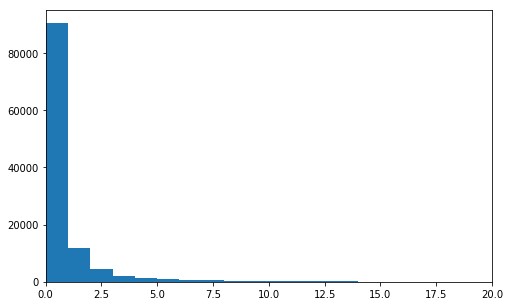

```python
loans['CurrentDelinquencies'] = loans['CurrentDelinquencies'].fillna(0.0).astype(int)

binsize = 1
bins = np.arange(0, loans['CurrentDelinquencies'].max()+binsize, binsize)

plt.figure(figsize=[8, 5])
plt.hist(data = loans, x = 'CurrentDelinquencies', bins = bins)
plt.xlim(0, 20)
plt.show()
```

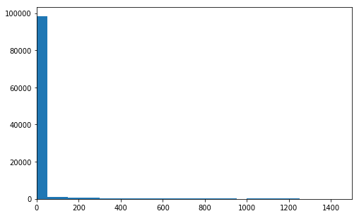

```python
loans['AmountDelinquent'] = loans['AmountDelinquent'].fillna(0.0).astype(int)

binsize = 50
bins = np.arange(0, loans['AmountDelinquent'].max()+binsize, binsize)

plt.figure(figsize=[8, 5])
plt.hist(data = loans, x = 'AmountDelinquent', bins = bins)
plt.xlim(0, 1500)
plt.show()
```

1. IncomeRange: 25,000-49,999 is the most common income range.

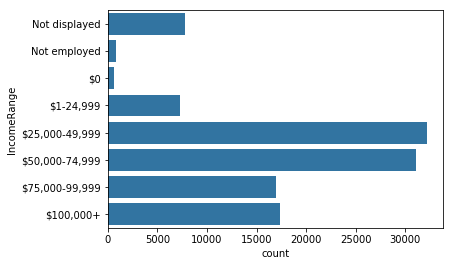

```python
base_color = sb.color_palette()[0]
sb.countplot(data = loans, y = 'IncomeRange', color = base_color)
```

1. StatedMonthlyIncome: 3000 - 4000 is the most common monthly income.

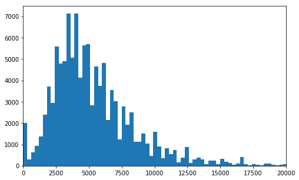

```python
loans['StatedMonthlyIncome'] = loans['StatedMonthlyIncome'].fillna(0.0).astype(int)

binsize = 300
bins = np.arange(0, loans['StatedMonthlyIncome'].max()+binsize, binsize)

plt.figure(figsize=[8, 5])
plt.hist(data = loans, x = 'StatedMonthlyIncome', bins = bins)
plt.xlim(0, 20000)
plt.show()
```

1. ListingCategory (numeric): the category of the listing that the borrower selected when posting their listing: 0 - Not Available, 1 - Debt Consolidation, 2 - Home Improvement, 3 - Business, 4 - Personal Loan, 5 - Student Use, 6 - Auto, 7- Other, 8 - Baby&Adoption, 9 - Boat, 10 - Cosmetic Procedure, 11 - Engagement Ring, 12 - Green Loans, 13 - Household Expenses, 14 - Large Purchases, 15 - Medical/Dental, 16 - Motorcycle, 17 - RV, 18 - Taxes, 19 - Vacation, 20 - Wedding. The most common category is Debt Consolidation.

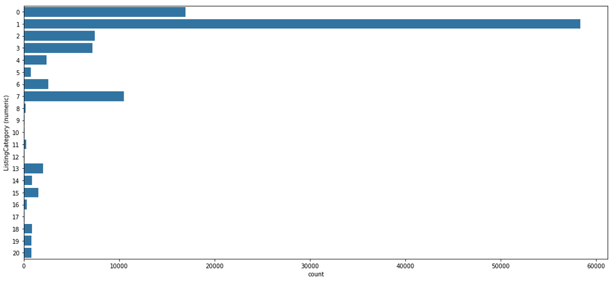

```python
plt.figure(figsize=[18, 8])
base_color = sb.color_palette()[0]
sb.countplot(data = loans, y = 'ListingCategory (numeric)', color = base_color)
```

```python
loans.RevolvingCreditBalance.value_counts()
```

```
0.0         4059
59.0          36
39.0          32
75.0          27
3.0           26
300.0         25
200.0         25
4.0           23
9.0           22
10.0          22
400.0         22
500.0         22
19.0          22
6.0           21
298.0         21
144.0         20
179.0         20
50.0          20
80.0          19
7.0           19
640.0         19
278.0         19
204.0         19
25.0          19
491.0         19
202.0         19
81.0          18
29.0          18
8.0           18
292.0         18
            ...
26793.0        1
29541.0        1
90791.0        1
15445.0        1
30658.0        1
13393.0        1
26060.0        1
22393.0        1
34987.0        1
29547.0        1
297490.0       1
107141.0       1
102148.0       1
14964.0        1
38681.0        1
116032.0       1
11457.0        1
123531.0       1
124016.0       1
74389.0        1
90765.0        1
30659.0        1
37191.0        1
90767.0        1
65608.0        1
45385.0        1
12802.0        1
20093.0        1
39688.0        1
106393.0       1
Name: RevolvingCreditBalance, Length: 38555, dtype: int64
```

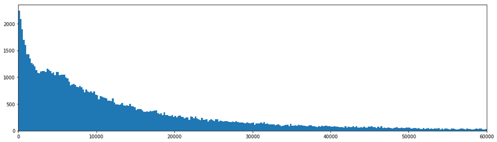

```python
# start with a standard-scaled plot

loans['RevolvingCreditBalance'] = loans['RevolvingCreditBalance'].fillna(0.0)
loans_resolved = loans[loans['RevolvingCreditBalance'] != 0]

binsize = 200
bins = np.arange(0, loans_resolved['RevolvingCreditBalance'].max()+binsize, binsize)

plt.figure(figsize=[18, 5])
plt.hist(data = loans_resolved, x = 'RevolvingCreditBalance', bins = bins)
plt.xlim(0, 60000)
plt.show()
```

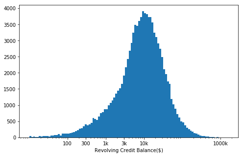

```python
# transfer to a log scale figure

log_binsize = 0.05
bins = 10 ** np.arange(1, np.log10(loans_resolved['RevolvingCreditBalance'].max())+log_binsize, log_binsize)

plt.figure(figsize=[8, 5])
plt.hist(data = loans_resolved, x = 'RevolvingCreditBalance', bins = bins)
plt.xscale('log')
plt.xticks([100, 300, 1e3, 3e3, 1e4, 1e6], [100, 300, '1k', '3k', '10k', '1000k'])
plt.xlabel('Revolving Credit Balance($)')
plt.show()
```

1. LoanOriginalAmount: the origination amount of the loan.

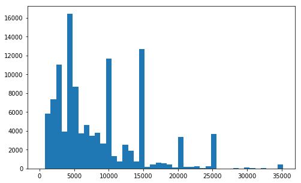

```python
loans['LoanOriginalAmount'] = loans['LoanOriginalAmount'].fillna(0.0).astype(int)

binsize = 800
bins = np.arange(0, loans['LoanOriginalAmount'].max()+binsize, binsize)

plt.figure(figsize=[8, 5])
plt.hist(data = loans, x = 'LoanOriginalAmount', bins = bins)
#plt.xlim(0, 20000)
plt.show()
```

## Bivariate Exploration

1. To start off with, I want to look at the pairwise correlations present between features in the data.

```python
numeric_vars = ['BorrowerAPR', 'BorrowerRate', 'LenderYield', 'EmploymentStatusDuration', 'OpenRevolvingMonthlyPayment',
                'DebtToIncomeRatio', 'StatedMonthlyIncome', 'MonthlyLoanPayment', 'LoanOriginalAmount']
categoric_vars = ['Loan_status_new', 'CreditGrade', 'Term', 'ProsperRating (Alpha)', 'ListingCategory (numeric)',
                  'EmploymentStatus', 'IncomeRange']
```

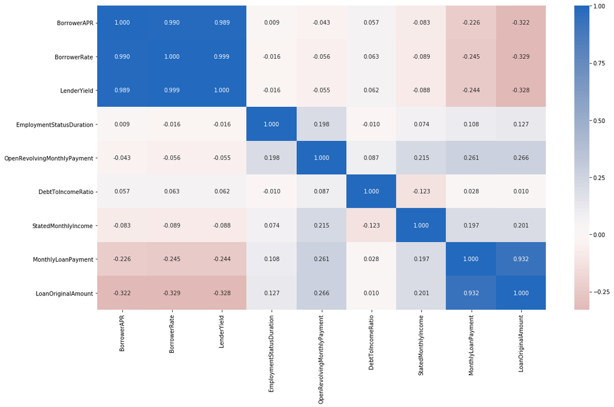

```python
# correlation plot
plt.figure(figsize = [18, 10])
sb.heatmap(loans[numeric_vars].corr(), annot = True, fmt = '.3f',
           cmap = 'vlag_r', center = 0)
plt.show()
```

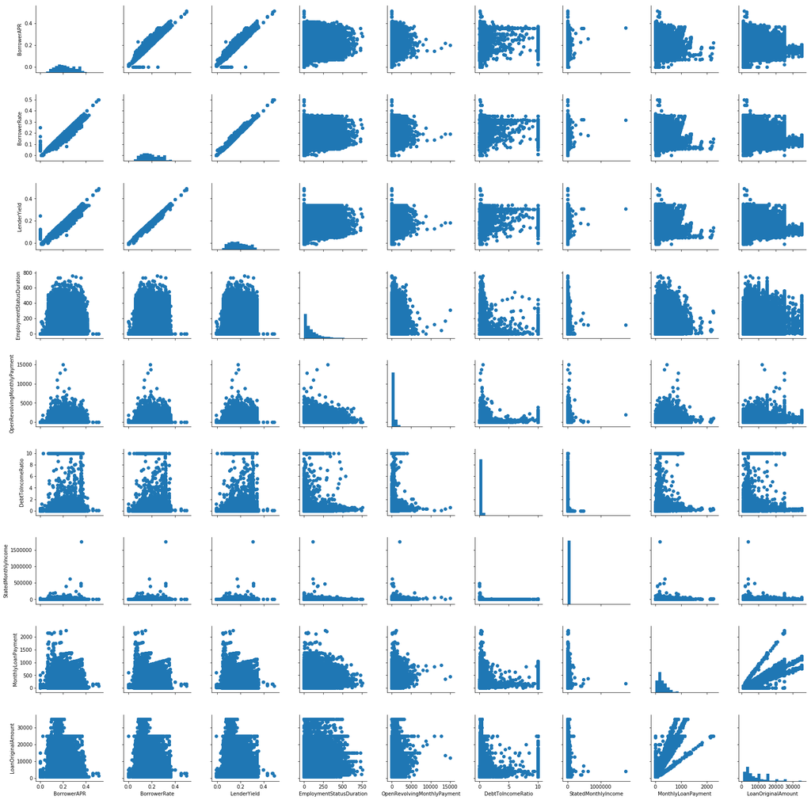

```python
# plot matrix: sample 500 loans so that plots are clearer and
# they render faster
samples = np.random.choice(loans.shape[0], 500, replace = False)
loans_samp = loans.loc[samples,:]

g = sb.PairGrid(data = loans, vars = numeric_vars)
g = g.map_diag(plt.hist, bins = 20);
g.map_offdiag(plt.scatter)
```

1. Plot of BorrowerAPR vs. Loan_status

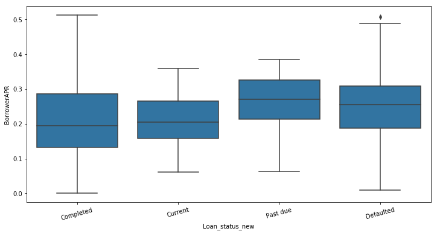

```python
# Plot of BorrowerAPR vs. Loan_status

plt.figure(figsize = [12, 6])
base_color = sb.color_palette()[0]
sb.boxplot(data = loans, x = 'Loan_status_new', y = 'BorrowerAPR', color = base_color)
plt.xticks(rotation = 15)
```

1. Plot of LoanOriginalAmount vs. Loan_status

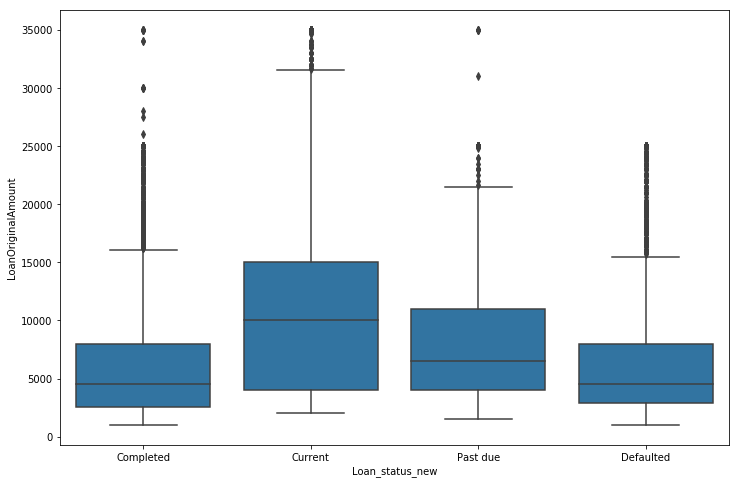

```python
plt.figure(figsize = [12, 8])
base_color = sb.color_palette()[0]
sb.boxplot(data = loans, x = 'Loan_status_new', y = 'LoanOriginalAmount', color = base_color)
```

1. Plot of BorrowerAPR vs. BorrowerRate

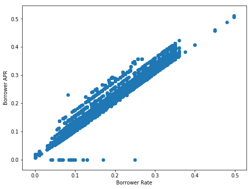

```python
# scatter plot of BorrowerAPR vs. BorrowerRate

plt.figure(figsize = [8, 6])
plt.scatter(data = loans, x = 'BorrowerRate', y = 'BorrowerAPR')
plt.xlabel('Borrower Rate')
plt.ylabel('Borrower APR')
plt.show()
```

1. Plot of BorrowerAPR vs. LenderYield

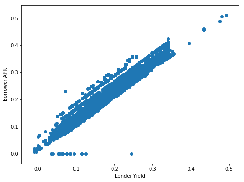

```python
# scatter plot of BorrowerAPR vs. LenderYield

plt.figure(figsize = [8, 6])
plt.scatter(data = loans, x = 'LenderYield', y = 'BorrowerAPR')
plt.xlabel('Lender Yield')
plt.ylabel('Borrower APR')
plt.show()
```

1. Plot of BorrowerAPR vs. EstimatedEffectiveYield

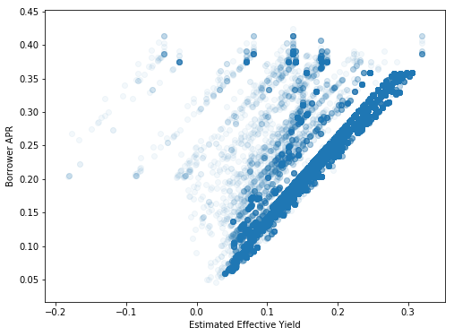

```python
# scatter plot of BorrowerAPR vs. EstimatedEffectiveYield

plt.figure(figsize = [8, 6])
plt.scatter(data = loans, x = 'EstimatedEffectiveYield', y = 'BorrowerAPR', alpha = 1/20)
plt.xlabel('Estimated Effective Yield')
plt.ylabel('Borrower APR')
plt.show()
```

1. Plot of BorrowerAPR vs. CreditGrade

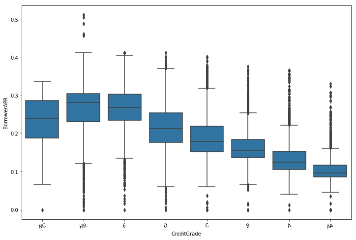

```python
# scatter plot of BorrowerAPR vs. CreditGrade

plt.figure(figsize = [12, 8])
base_color = sb.color_palette()[0]
sb.boxplot(data = loans[loans['DatePhase'] == 'Before 2009'], x = 'CreditGrade', y = 'BorrowerAPR', color = base_color)
plt.xticks(rotation = 15)
```

1. Plot of BorrowerAPR vs. ProsperRating (Alpha)

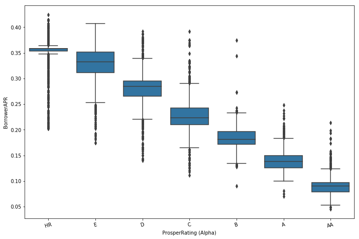

```python
# scatter plot of BorrowerAPR vs. ProsperRating (Alpha)

plt.figure(figsize = [12, 8])
base_color = sb.color_palette()[0]
sb.boxplot(data = loans[loans['DatePhase'] == 'After 2009'], x = 'ProsperRating (Alpha)', y = 'BorrowerAPR', color = base_color)
plt.xticks(rotation = 15)
```

1. Plot of BorrowerAPR vs. ListingCategory (numeric)

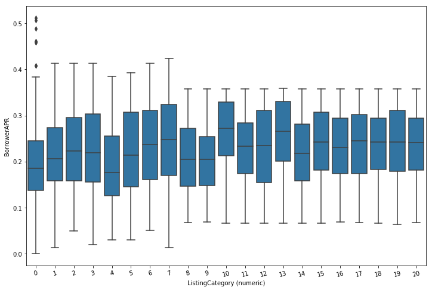

```python
# boxplot of BorrowerAPR vs. ListingCategory (numeric)

plt.figure(figsize = [12, 8])
base_color = sb.color_palette()[0]
sb.boxplot(data = loans, x = 'ListingCategory (numeric)', y = 'BorrowerAPR', color = base_color)
plt.xticks(rotation = 15)
```

1. Plot of BorrowerAPR vs. EmploymentStatus

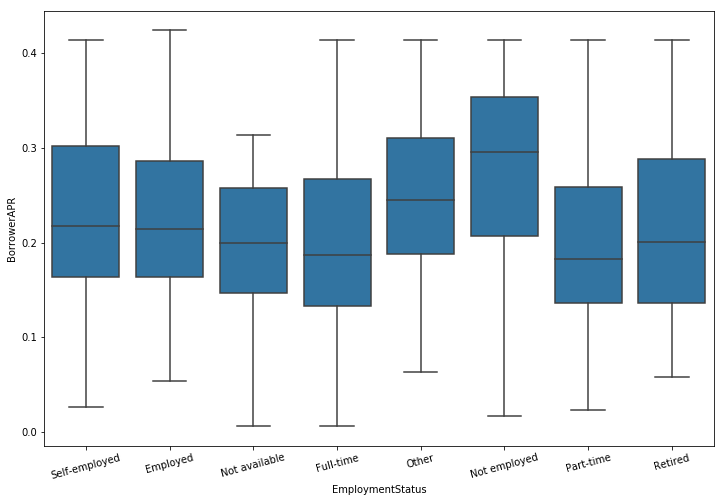

```python
# boxplot of BorrowerAPR vs. EmploymentStatus

plt.figure(figsize = [12, 8])
base_color = sb.color_palette()[0]
sb.boxplot(data = loans, x = 'EmploymentStatus', y = 'BorrowerAPR', color = base_color)
plt.xticks(rotation = 15)
```

1. Plot of BorrowerAPR vs. IncomeRange

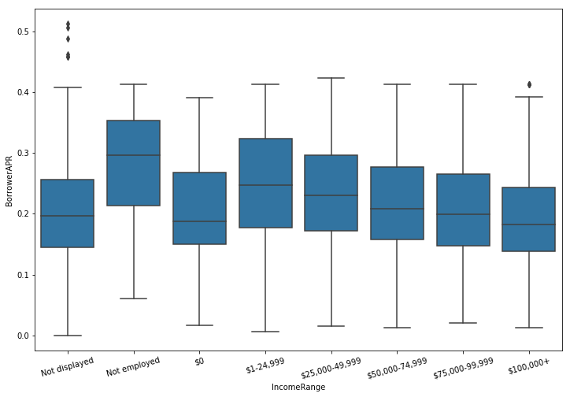

```python
# boxplot of BorrowerAPR vs. IncomeRange

plt.figure(figsize = [12, 8])
base_color = sb.color_palette()[0]
sb.boxplot(data = loans, x = 'IncomeRange', y = 'BorrowerAPR', color = base_color)
plt.xticks(rotation = 15)
```

## Multivariate Exploration

1. Plot of Income range vs loan status.

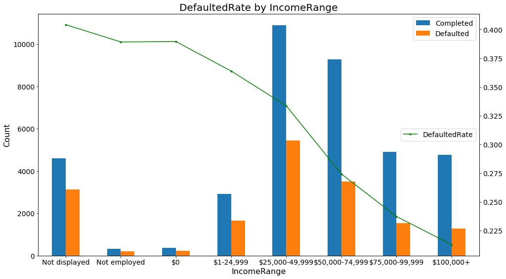

```python
#count using groupby
data1=loans.groupby(['IncomeRange','Loan_status_new'])['Loan_status_new'].count().unstack()
data1=data1.reindex(['Not displayed', 'Not employed','$0','$1-24,999','$25,000-49,999','$50,000-74,999','$75,000-99,999','$100,000+'])
#the percentage of defaulted loans
data1['DefaultedRate']=data1['Defaulted']/(data1['Defaulted']+data1['Completed'])

f,ax1=plt.subplots(figsize=(16,9))
data1[['Completed','Defaulted']].plot(kind='bar',ax=ax1,rot=0,fontsize=14)
ax2=ax1.twinx()
data1['DefaultedRate'].plot(ax=ax2,style='g.-',fontsize=14)
plt.title('DefaultedRate by IncomeRange',fontsize=20)
ax1.set_xlabel('IncomeRange',fontsize=16)
ax1.set_ylabel('Count',fontsize=16)
ax2.legend(loc='center right',fontsize=14)
ax1.legend(fontsize=14)
plt.savefig("DefaultedRate by IncomeRange")
```

#### As shown by the figure, middle-income people inclinded to have more loans compared to other people owning less or more. On the other hand, the defaulted rate of loans decreases as the income increases. In other words, borrowers with higher income are more likely to complete the loan in time.

1. Plot of EmploymentStatusDuration vs loan status.

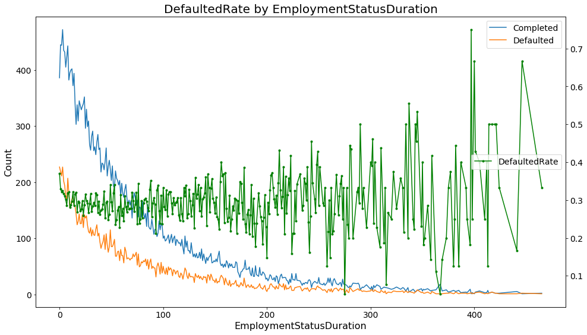

```python
data2=loans.groupby(['EmploymentStatusDuration','Loan_status_new'])['Loan_status_new'].count().unstack()
data2['DefaultedRate']=data2['Defaulted']/(data2['Defaulted']+data2['Completed'])
data2=data2.dropna(how='any',axis=0)
f,ax1=plt.subplots(figsize=(16,9))
data2[columns].plot(kind='line',ax=ax1,rot=0,fontsize=14)
ax1.set_xlabel('EmploymentStatusDuration',fontsize=16)
ax1.set_ylabel('Count',fontsize=16)
ax2=ax1.twinx()
data2['DefaultedRate'].plot(style='g.-',ax=ax2,fontsize=14)
ax1.legend(fontsize=14)
ax2.legend(loc='center right',fontsize=14)
plt.title('DefaultedRate by EmploymentStatusDuration',fontsize=20)
plt.savefig('DefaultedRate by EmploymentStatusDuration')
```

#### Obviously the number of the loans decreases as the employment duration increases. This makes good sense, since the financial situation will be more steady as people are employed for longer period of time. On the other hand, there is no correlationship between the defaulted rate of the loans and the employment status duration.

1. Plot of DebtToIncomeRatio vs loan status.

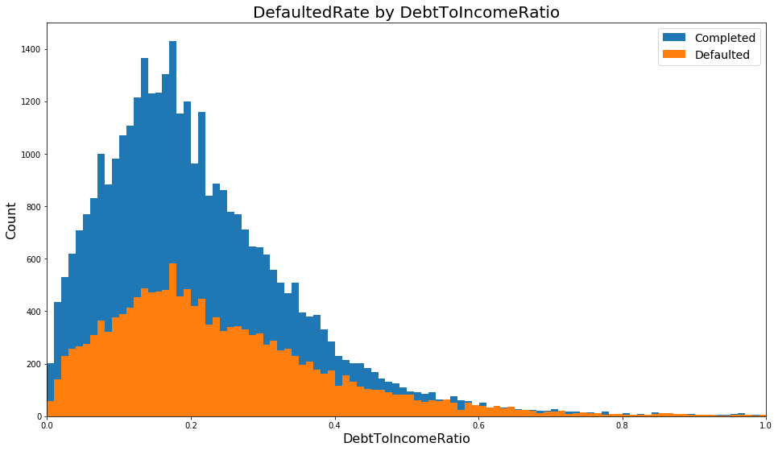

```python
f,ax=plt.subplots(figsize=(16,9))
loans.loc[loans['Loan_status_new']=='Completed','DebtToIncomeRatio'].plot(kind='hist',bins=1000,ax=ax,label='Completed')
loans.loc[loans['Loan_status_new']=='Defaulted','DebtToIncomeRatio'].plot(kind='hist',bins=1000,ax=ax,label='Defaulted')
plt.xlim(0,1)
plt.legend(loc='best',fontsize=14)
ax.set_xlabel('DebtToIncomeRatio',fontsize=16)
ax.set_ylabel('Count',fontsize=16)
ax.set_title('DefaultedRate by DebtToIncomeRatio',fontsize=20)
plt.savefig("DefaultedRate by DebtToIncomeRatio')
```

#### When debt-to-income ratio is smaller than 0.6, the defaulted loans are much less than the completed loans, however, as the ration increases, there is no big difference between defaulted and completed loans. In some cases, the number of defaulted loans can even be higher than completed loans. This figure suggested that it's easy for people with higher debit-to-income ratio to have defaulted loans.

1. Plot of BankcardUse vs loan status.

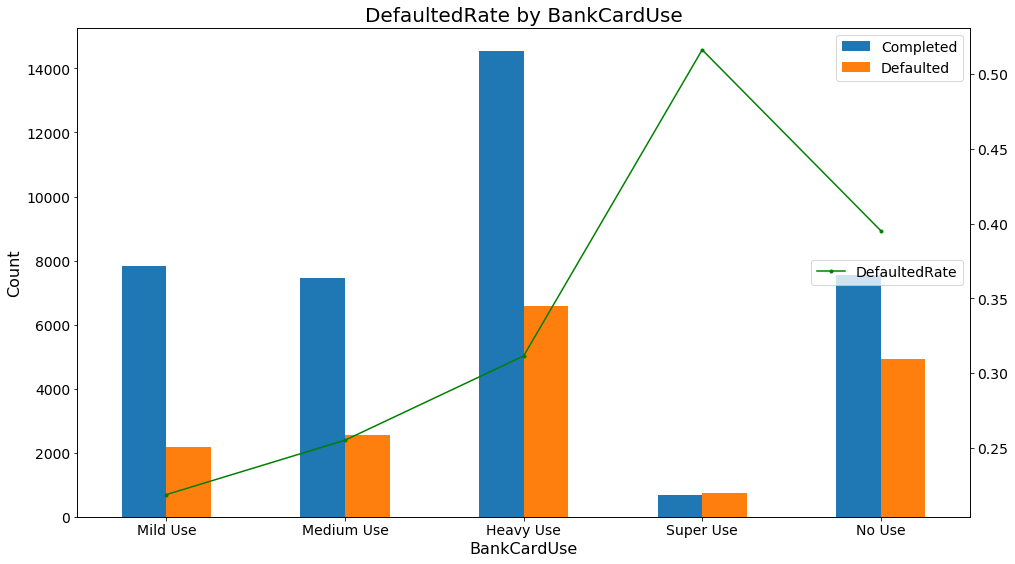

```python
#count the number of defaulted and completed loans when grouped by the bankcarduse values
data3=loans.groupby(['BankcardUse','Loan_status_new'])['Loan_status_new'].count().unstack()
data3=data3.reindex(['Mild Use','Medium Use','Heavy Use','Super Use','No Use'])
columns=['Completed','Defaulted']
#calculate the defaulted percentage
data3['DefaultedRate']=data3['Defaulted']/(data3['Defaulted']+data3['Completed'])

f,ax1=plt.subplots(figsize=(16,9))
data3[columns].plot(kind='bar',ax=ax1,rot=0,fontsize=14)
ax1.set_xlabel('BankCardUse',fontsize=16)
ax1.set_ylabel('Count',fontsize=16)
ax2=ax1.twinx()
data3['DefaultedRate'].plot(style='g.-',ax=ax2,fontsize=14)
ax1.legend(fontsize=14)
ax2.legend(loc='center right',fontsize=14)
plt.title('DefaultedRate by BankCardUse',fontsize=20)
plt.savefig(r'e:python\p2p\DefaultedRate by BankCardUse')
```

#### Generally speaking, the default rate of the loans increases as the bank card use rate increases. It's worth to note that people who are super users of bankcard have a default rate as high as 50%, suggesting that more strict review and supervision procesure should be applied for these people. In addition, loans to people missing bank card use details can be risky as well, since the default rate is as high as 40%, suggesting that the information of bank card use is definitely a very important criteria for loan assessment.

1. Plot of CreditGrade vs loan status (before July 2009).

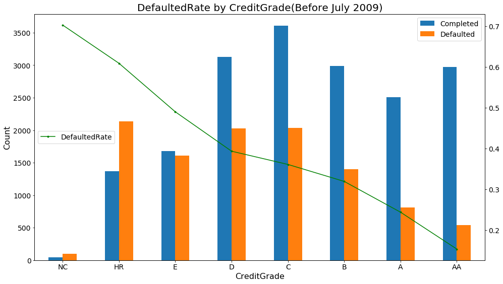

```python
data4=loans.groupby(['CreditGrade','Loan_status_new'])['Loan_status_new'].count().unstack()
data4=data4.reindex(['NC','HR','E','D','C','B','A','AA'])
data4['DefaultedRate']=data4['Defaulted']/(data4['Defaulted']+data4['Completed'])
f,ax1=plt.subplots(figsize=(16,9))
data4[columns].plot(kind='bar',ax=ax1,rot=0,fontsize=14)
ax1.set_xlabel('CreditGrade',fontsize=16)
ax1.set_ylabel('Count',fontsize=16)
ax2=ax1.twinx()
data4['DefaultedRate'].plot(style='g.-',ax=ax2,fontsize=14)
ax1.legend(fontsize=14)
ax2.legend(loc='center left',fontsize=14)
plt.title('DefaultedRate by CreditGrade(Before July 2009)',fontsize=20)
plt.savefig('DefaultedRate by CreditGrade(Before July 2009)')
```

#### Before July 2009, the default rate of loans decreases as the credit grade increases. Majority of the borrowers have a credit grade higher than D.

1. Plot of ProsperRating (Alpha) vs loan status (After July 2009).

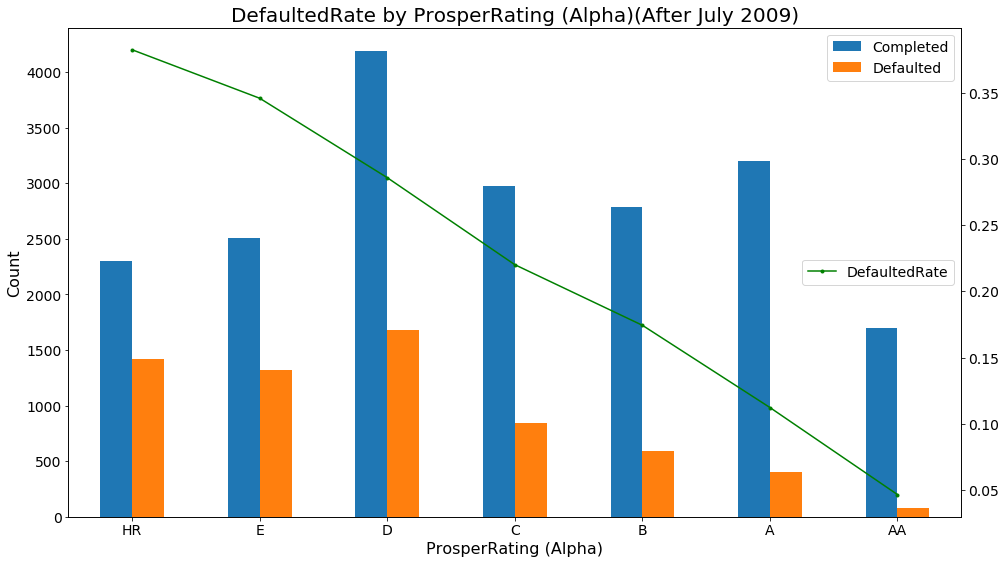

```python
data5=loans.groupby(['ProsperRating (Alpha)','Loan_status_new'])['Loan_status_new'].count().unstack()
data5=data5.reindex(['HR','E','D','C','B','A','AA'])
data5['DefaultedRate']=data5['Defaulted']/(data5['Defaulted']+data5['Completed'])

f,ax1=plt.subplots(figsize=(16,9))
data5[columns].plot(kind='bar',ax=ax1,rot=0,fontsize=14)
ax1.set_xlabel('ProsperRating (Alpha)',fontsize=16)
ax1.set_ylabel('Count',fontsize=16)
ax2=ax1.twinx()
data5['DefaultedRate'].plot(style='g.-',ax=ax2,fontsize=14)
ax1.legend(fontsize=14)
ax2.legend(loc='center right',fontsize=14)
plt.title('DefaultedRate by ProsperRating (Alpha)(After July 2009)',fontsize=20)
plt.savefig('DefaultedRate by ProsperRating (Alpha)(After July 2009)')
```

#### After July 2009, the default rate of loans decreases as the Prosper rating increases. Compared with the defaulted rate before July 2009, the rate is significantly decreased with the application of the new credit rating system.

1. Plot of DelinquenciesLast7Years vs loan status.

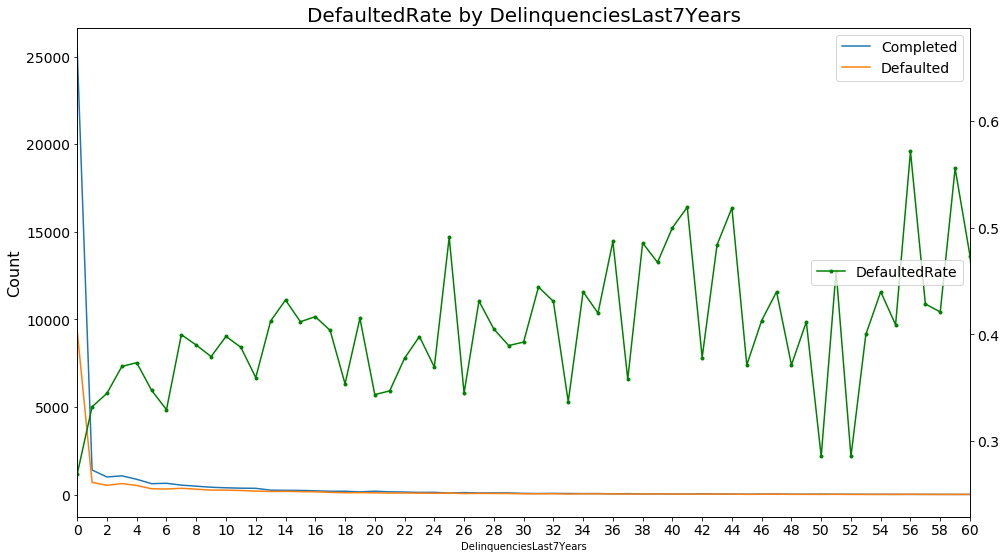

```python
data6=loans.groupby(['DelinquenciesLast7Years','Loan_status_new'])['Loan_status_new'].count().unstack()
data6['DefaultedRate']=data6['Defaulted']/(data6['Defaulted']+data6['Completed'])

f,ax1=plt.subplots(figsize=(16,9))
data6[columns].plot(kind='line',ax=ax1,rot=0,fontsize=14)
ax1.set_xlabel('DelinquenciesLast7Years')
ax1.set_ylabel('Count',fontsize=16)
ax1.set_xticks(range(0,100,2))
ax1.set_xticklabels(range(0,100,2))
ax1.set_xlim(0,60)
ax2=ax1.twinx()
data6['DefaultedRate'].plot(style='g.-',ax=ax2,fontsize=14)
ax1.legend(fontsize=14)
ax2.legend(loc='center right',fontsize=14)
plt.title('DefaultedRate by DelinquenciesLast7Years',fontsize=20)
plt.savefig('DefaultedRate by DelinquenciesLast7Years')
```

#### As you can image, the defaulted rate of the loans increases as the delinquencies increase.

1. Plot of BorrowerAPR vs loan status.

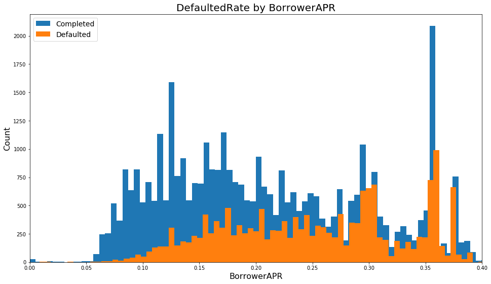

```python
f,ax=plt.subplots(figsize=(16,9))
loans.loc[loans['Loan_status_new']=='Completed','BorrowerAPR'].plot(kind='hist',bins=100,ax=ax,label='Completed')
loans.loc[loans['Loan_status_new']=='Defaulted','BorrowerAPR'].plot(kind='hist',bins=100,ax=ax,label='Defaulted')
plt.xlim(0,0.4)
plt.legend(loc='best',fontsize=14)
ax.set_xlabel('BorrowerAPR',fontsize=16)
ax.set_ylabel('Count',fontsize=16)
ax.set_title('DefaultedRate by BorrowerAPR',fontsize=20)
plt.savefig('DefaultedRate by BorrowerAPR')
```

#### Generally speaking, the defaulted rate gradually increases as the BorrowerAPR increases.

1. Plot of LoanOriginalAmount vs loan status.

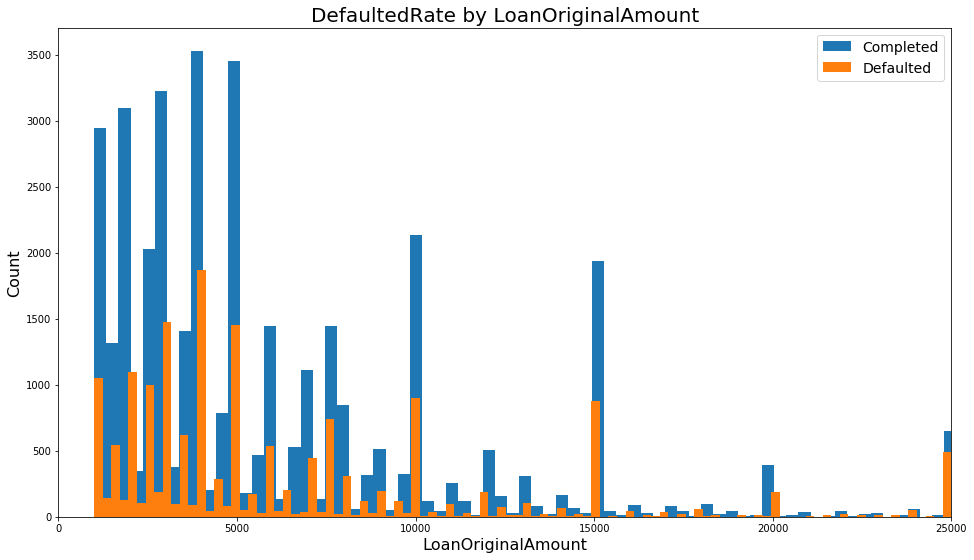

```python
f,ax=plt.subplots(figsize=(16,9))
loans.loc[loans['Loan_status_new']=='Completed','LoanOriginalAmount'].plot(kind='hist',bins=100,ax=ax,label='Completed')
loans.loc[loans['Loan_status_new']=='Defaulted','LoanOriginalAmount'].plot(kind='hist',bins=100,ax=ax,label='Defaulted')
plt.xlim(0,25000)
plt.legend(loc='best',fontsize=14)
ax.set_xlabel('LoanOriginalAmount',fontsize=16)
ax.set_ylabel('Count',fontsize=16)
ax.set_title('DefaultedRate by LoanOriginalAmount',fontsize=20)
plt.savefig('DefaultedRate by LoanOriginalAmount')
```

#### There is no apparent relationship between LoanOriginalAmount and the defaulted rate.

1. Plot of BorrowerAPR vs DebtToIncomeRatio and ProsperRating (Alpha).

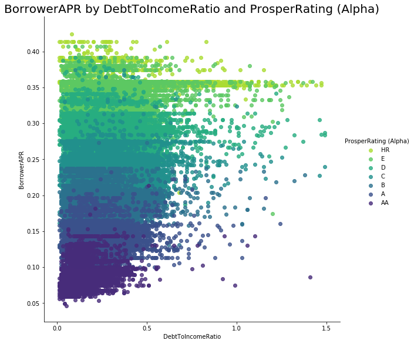

```python
data7=loans[(loans.DebtToIncomeRatio > 0.0) & (loans.DebtToIncomeRatio < 1.5)]
g = sb.FacetGrid(data = data7, hue = 'ProsperRating (Alpha)', palette = 'viridis_r', size = 8)
g = g.map(sb.regplot, 'DebtToIncomeRatio', 'BorrowerAPR', fit_reg = False)
g.add_legend()
plt.xlabel('DebtToIncomeRatio')
plt.xticks([0.0, 0.5, 1.0, 1.5])
plt.ylabel('BorrowerAPR')
plt.title('BorrowerAPR by DebtToIncomeRatio and ProsperRating (Alpha)',fontsize=20)
plt.savefig('BorrowerAPR by DebtToIncomeRatio and ProsperRating (Alpha)')
```

#### According to this plot, ‘A’ category loans seem to have a lower APRs and a smaller range of debt-to-income ratios, both of which indicate less risk. The rest of the plot follow the color palette and APR increases as the rating gets riskier. In addition, most people tend to have debt-to-income ratios below 1, regardless of risk category. Also, there is this unusual horizontal line in the ‘HR’ category that extends past 1 and all the way to 1.5, while lower ratings tend to be sparse in the 1.0+ debt-to-income ratio range.